# Part II -2017 Ford GoBike analysis

## by Mubarak Agboola

## Investigation Overview

> We explored the dataset provided by Ford for its 2017 GoBike program in order to conduct our investigation. We examined issues and discoveries that can be better grasped with the use of visuals.

## Dataset Overview

> The dataset, 2017-fordgobike-tripdata.csv, is downloaded from Ford GoBike and licensed by Ford GoBike. This dataset includes 519,700 trips with 13 features such as locations, time, and user_type. There are start and end stations.

## (Visualization 1)

> **Duration of trips by different types of users**

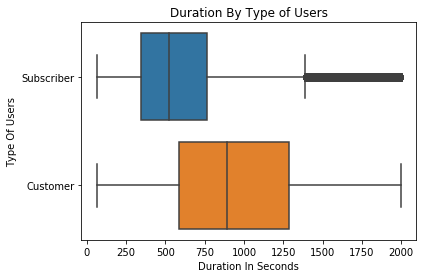

Observation: According to the data, ordinary customers have lengthier rides than subscribers do on average.

## (Visualization 2)

> **The proportion of user types in the dataset**

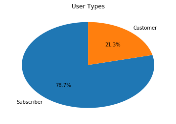

Observation: 79% of the users are members(subscribers) and about 21% are casuals(customer)

## (Visualization 3)

> **The top five ride starting points**

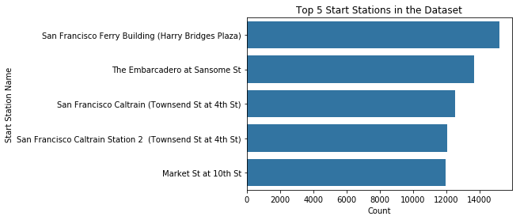

The stations with the most trips are located in San Francisco and connect to public transportations including Caltrain and Ferry.